# Final Project Practical Machine Learning

William Paredes

15/9/2020

## Background

With devices like the Jawbone Up, Nike FuelBand, and Fitbit, it is now possible to collect a large amount of personal activity data relatively inexpensively. These types of devices are part of quantified self-movement: a group of enthusiasts who regularly take action on themselves to improve their health, to find patterns in their behavior or because they are fanatics of technology.

One thing that people do on a regular basis is quantify how much of a particular activity they do, but they rarely quantify how well they do it.

In this project, your goal will be to use accelerometer data on the belt, forearm, arm, and dumbbell from 6 participants.

They were asked to perform correctly and incorrectly barbell lifts in 5 different ways. More information is available on the website here: http://groupware.les.inf.puc-rio.br/har (see section on the weightlifting exercise dataset).

### Loading Libraries

- library(tidyverse)
- library(caret)
- library(corrplot)
- library(rpart)
- library(reshape2)
- library(ROCR)
- library(rattle)

### Loading Data

```r
training <- read.csv("training.csv", header = TRUE)
testing <- read.csv("testing.csv", header = TRUE)
```

### Explore and Cleaning

```r
dim(training)  #19622   161
```

```
## [1] 19622   161
```

```r
dim(testing)   #20 161
```

```
## [1]  20 161
```

#### As shown below there are 19622 observations and 161 variables in the Training dataset

### Transform to factor

#### Because it is a categorical prediction

```r
training$classe <- as.factor(training$classe)
```

#### Clean the data of the columns that have NA and do not work

```r
training$X.1 <- NULL
testing$X.1 <- NULL

training <- training[,colSums(is.na(training)) == 0]
testing <- testing[,colSums(is.na(testing)) == 0]
```

#### The firts 7 columns are useless

```r
training[,c(1:7)] <- NULL
testing[,c(1:7)] <- NULL
```

#### Create a test partition in the training one since the test partition is very small and I can fall into an overfitting.

```r
index <- createDataPartition(training$classe, times = 1, p = 0.7, list = FALSE)

training_wp <-  training[index,]
testing_wp <- training[-index,]
```

#### Delete zerovar function caret package

```r
zerovar_wp <- nearZeroVar(training_wp)

training_wp <- training_wp[, -zerovar_wp]
testing_wp <- testing_wp[, -zerovar_wp]
```

#### Finding correlations in the data

```r
training_cor <- cor(training_wp[,c(1:52)], method = "pearson")
```

- round(training_cor, digits = 2)

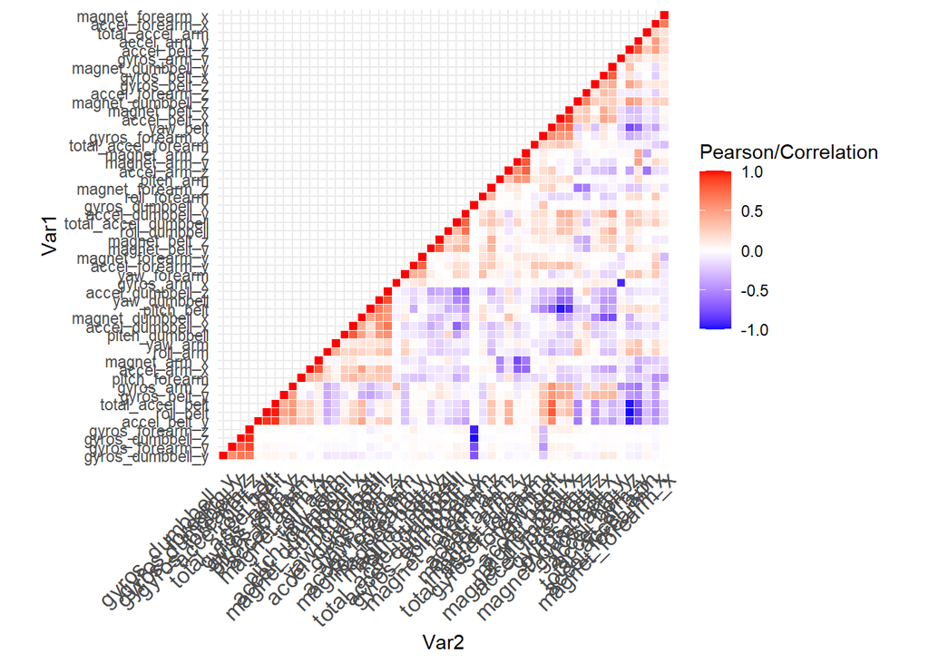

```r
training_melted <- melt(training_cor)

get_lower_triangle <- function(cormat) {
  cormat[upper.tri(cormat)] <- NA
  return(cormat)
}
get_upper_triangle <- function(cormat) {
  cormat[lower.tri(cormat)] <- NA
  return(cormat)
}
reorder_cormat <- function(cormat){
  dd <- as.dist((1-cormat)/2)
  hc <-  hclust(dd)
  cormat <- cormat[hc$order, hc$order]
}
cormat <- reorder_cormat(training_cor)
cormat_ut <- get_upper_triangle(cormat)
cormat_ut_melted <- melt(cormat_ut, na.rm = TRUE)

cormat_ut_melted %>% ggplot(aes(Var2, Var1, fill = value)) +
  geom_tile(color = "white") +
  scale_fill_gradient2(low = "blue", high = "red", mid = "white",
                       midpoint = 0, limit = c(-1,1), space = "Lab",
                       name = "Pearson/Correlation") + theme_minimal() +
  theme(axis.text.x = element_text(angle = 45, vjust = 1, size = 12, hjust = 1)) +
  coord_fixed()
```

#### Find the correlation > 0.80

```r
train_hight_correlation <- findCorrelation(cormat, cutoff = 0.80)
names(training_wp)[train_hight_correlation]
```

```
##  [1] "accel_forearm_y"      "gyros_belt_y"         "gyros_belt_x"
##  [4] "gyros_arm_z"          "roll_forearm"         "gyros_arm_x"
##  [7] "magnet_belt_x"        "yaw_arm"              "accel_dumbbell_y"
## [10] "pitch_belt"           "total_accel_dumbbell" "yaw_belt"
## [13] "accel_arm_x"
```

#### Separating highly correlated columns

```r
training_wp_hc <- training_wp[train_hight_correlation]
training_wp_hc$classe <- training_wp$classe

testing_wp_hc <- testing_wp[train_hight_correlation]
testing_wp_hc$classe <- testing_wp$classe
```

## Model Building

To build the predictive model of the project, search online which were the most used algorithms for this type of categorical prediction, of which I chose the following:

### 1. Random Forest (RF)

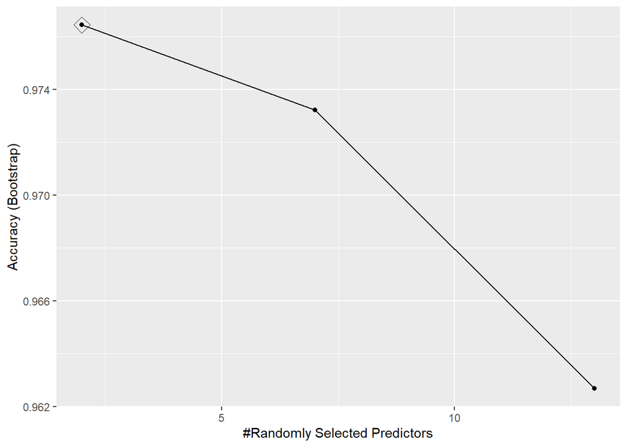

```r
fit_rf <- train(classe~., data = training_wp_hc, method = "rf" )
predict_rf <- predict(fit_rf, testing_wp_hc)
cm_rf <- confusionMatrix(predict_rf, testing_wp_hc$classe)$overall["Accuracy"]

ggplot(fit_rf, highlight = TRUE)
```

### 2. Neural Network (NNET)

- fit_nnet <- train(classe~., data = training_wp_hc, method = “nnet”)

```r
predict_nnet <- predict(fit_nnet, testing_wp_hc)
cm_nnet <- confusionMatrix(predict_nnet, testing_wp_hc$classe)$overall["Accuracy"]
```

```r
fit_lda <- train(classe~., data = training_wp_hc, method = "lda")
predict_lda <- predict(fit_lda, testing_wp_hc)
cm_lda <- confusionMatrix(predict_lda, testing_wp_hc$classe)$overall["Accuracy"]
```

### 4. Gradient boosting (GBM)

- fit_gbm <- train(classe~.,data = training_wp_hc, method = “gbm”)

```r
predict_gbm <- predict(fit_gbm, testing_wp_hc)
cm_gmb <- confusionMatrix(predict_gbm, testing_wp_hc$classe)$overall["Accuracy"]
```

### 5. Decision Trees (RPART)

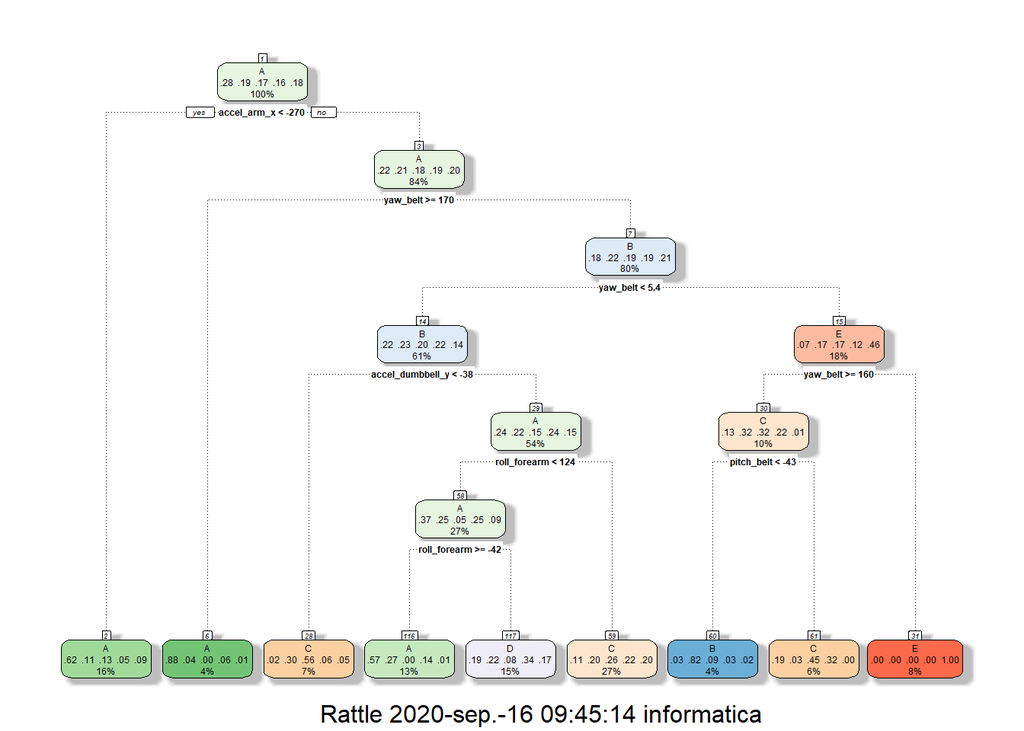

```r
fit_rpart <- train(classe~.,data = training_wp_hc, method = "rpart")
predict_rpart <- predict(fit_rpart, testing_wp_hc)
cm_rpart <- confusionMatrix(predict_rpart, testing_wp_hc$classe)$overall["Accuracy"]


fancyRpartPlot(fit_rpart$finalModel)
```

## General Accurancy

```r
cm_rf
```

```
## Accuracy
## 0.984537
```

```r
cm_nnet
```

```
##  Accuracy
## 0.3972812
```

```r
cm_lda
```

```
##  Accuracy
## 0.3892948
```

```r
cm_gmb
```

```
##  Accuracy
## 0.9017842
```

```r
cm_rpart
```

```
##  Accuracy
## 0.5126593
```

## Random Forest cross validation

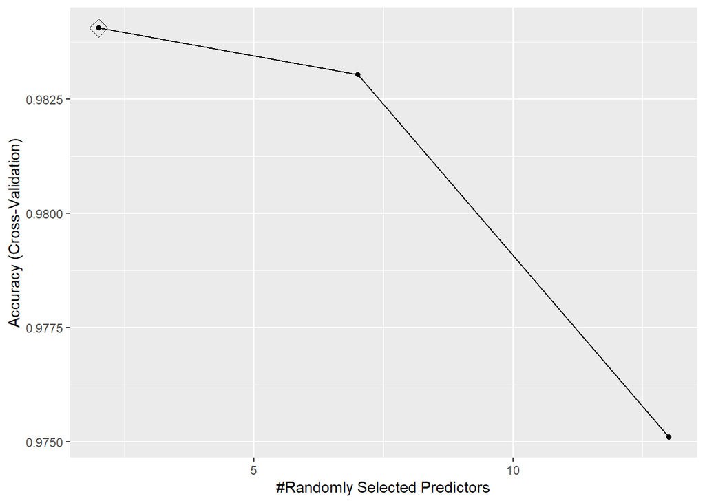

```r
control <- trainControl(method = "cv", number = 10, p = .9)

fit_rf_cv <- train(classe~., data = training_wp_hc, method = "rf", trControl = control )
predict_rf_cv <- predict(fit_rf_cv, testing_wp_hc)
cm_rf_cv <- confusionMatrix(predict_rf_cv, testing_wp_hc$classe)$overall["Accuracy"]
cm_rf_cv_total <- confusionMatrix(predict_rf_cv, testing_wp_hc$classe)

ggplot(fit_rf_cv, highlight = TRUE)
```

### Plotting Confusion Matrix for Random Forest Cross Validation

```r
table(testing_wp_hc$classe, predict_rf_cv, dnn = c("Actual", "Predict"))
```

```
##       Predict
## Actual    A    B    C    D    E
##      A 1665    0    3    6    0
##      B    9 1105   23    2    0
##      C    0   12 1009    5    0
##      D    3    2   10  949    0
##      E    0    4   10    7 1061
```

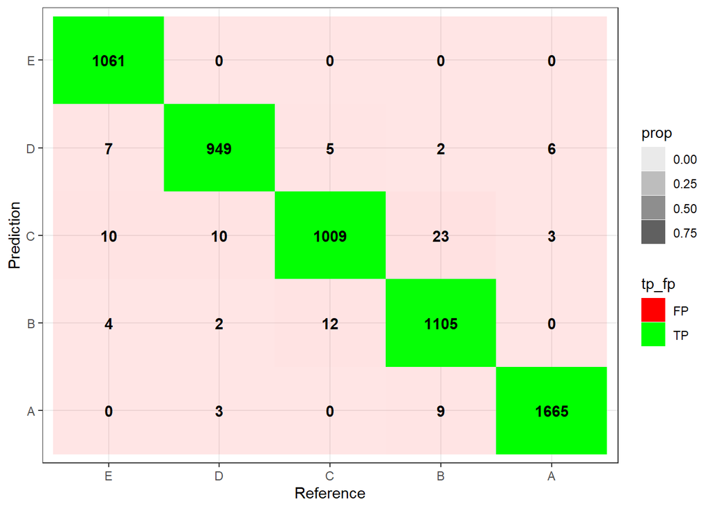

```r
table <- data.frame(confusionMatrix(predict_rf_cv, testing_wp_hc$classe)$table)

plotTable <- table %>%
  mutate(tp_fp = ifelse(table$Prediction == table$Reference, "TP", "FP")) %>%
  group_by(Reference) %>%
  mutate(prop = Freq/sum(Freq))

ggplot(data = plotTable, mapping = aes(x = Reference, y = Prediction, fill = tp_fp, alpha = prop)) +
  geom_tile() +
  geom_text(aes(label = Freq), vjust = .5, fontface  = "bold", alpha = 1) +
  scale_fill_manual(values = c(TP = "green", FP = "red")) +
  theme_bw() +
  xlim(rev(levels(table$Reference)))
```

### Combined two close models

```r
coincidencia <- predict_rf_cv == predict_gbm

Agreement_accuracy <- confusionMatrix(testing_wp_hc$classe[coincidencia], predict_rf[coincidencia])$overall["Accuracy"]


table(Agreement_accuracy)
```

```
## Agreement_accuracy
## 0.986411020104244
##                 1
```

#Obtain OOB error in:

The expected out of sample error is:

```r
summary(fit_rf_cv$finalModel$err.rate[,1])[4]
```

```
##       Mean
## 0.01976657
```

## Applying the best model to the validation data

```r
cm_rf_cv
```

```
##  Accuracy
## 0.9836873
```

```r
predict_test <- predict(fit_rf_cv, newdata=testing)
predict_test
```

```
##  [1] B A B A A E D B A A B C B A E E A B B B
## Levels: A B C D E
```